# pirateplot

Nathaniel Phillips

2017-04-18

# What is a pirateplot()?

A pirateplot, is the RDI (**Raw** data, **Descriptive** statistics, and **Inferential** statistics) plotting choice of R pirates who are displaying the relationship between 1 to 3 categorical independent variables, and one continuous dependent variable.

A pirateplot has 4 main elements

1. points, symbols representing the raw data (jittered horizontally)
2. bar, a vertical bar showing central tendencies
3. bean, a smoothed density (inspired by Kampstra and others (2008)) representing a smoothed density
4. inf, a rectangle representing an inference interval (e.g.; Bayesian Highest Density Interval or frequentist confidence interval)

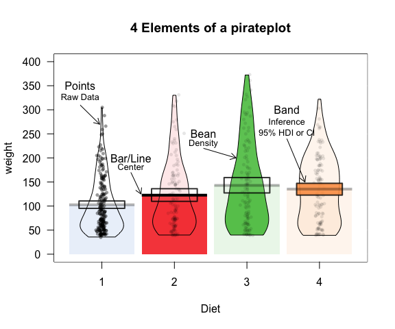

# Main arguments

Here are the main arguments to `pirateplot()`

Main Pirateplot Arguments

| Argument | Description | Examples |
| --- | --- | --- |
| formula | A formula | height ~ sex + eyepatch, weight ~ Time |
| data | A dataframe | pirates, ChickWeight |
| main | Plot title | ‘Pirate heights’, ’Chicken Weights |
| pal | A color palette | ‘xmen’, ‘black’ |
| theme | A plotting theme | 0, 1, 2 |
| inf | Type of inference | ‘ci’, ‘hdi’, ‘iqr’ |

# Themes

## Theme 1

`theme = 1` is the default

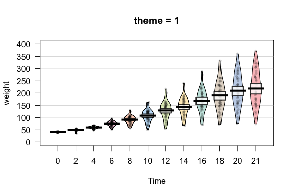

```r
# Theme 1 (the default)
pirateplot(formula = weight ~ Time,
           data = ChickWeight,
           theme = 1,
           main = "theme = 1")
```

## Theme 2

Here is `theme = 2`

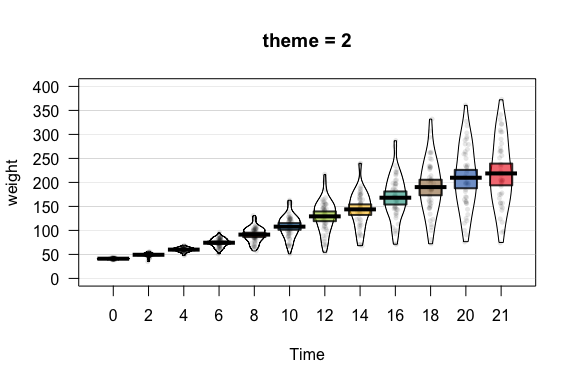

```r
# Theme 2
pirateplot(formula = weight ~ Time,
           data = ChickWeight,
           theme = 2,
           main = "theme = 2")
```

## Theme 3

And now…`theme = 3`!

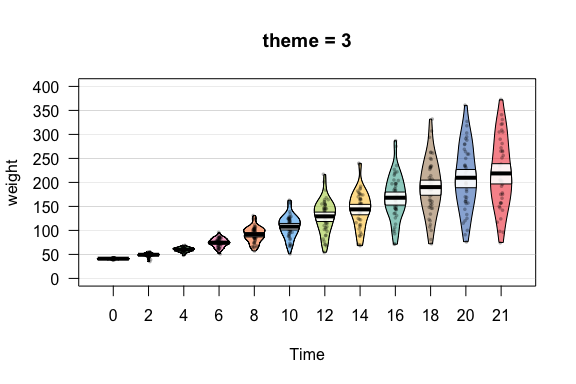

```r
# Theme 3
pirateplot(formula = weight ~ Time,
           data = ChickWeight,
           theme = 3,
           main = "theme = 3")
```

## Theme 4

`theme = 4` tries to maintain a classic barplot look (but with added raw data).

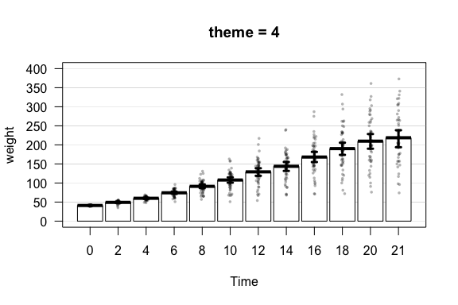

```r
# Theme 4
pirateplot(formula = weight ~ Time,
           data = ChickWeight,
           theme = 4,
           main = "theme = 4")
```

## Theme 0

`theme = 0` allows you to start a pirateplot from scratch – that is, it turns of *all* elements. You can then selectively turn elements on with individual arguments (e.g.; `bean.f.o`, `point.o`)

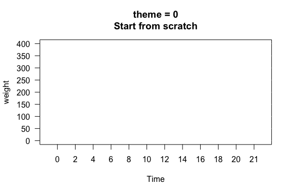

```r
# Default theme
pirateplot(formula = weight ~ Time,
           data = ChickWeight,
           theme = 0,
           main = "theme = 0\nStart from scratch")
```

# Color palettes

You can specify a general color palette using the `pal` argument. You can do this in two ways.

The first way is to specify the name of a color palette in the `piratepal()` function. Here they are:

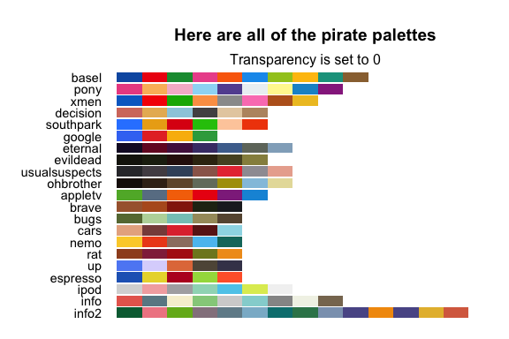

```r
piratepal("all")
```

For example, here is a pirateplot using the `"pony"` palette

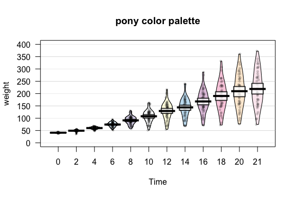

```r
pirateplot(formula = weight ~ Time,
           data = ChickWeight,
           pal = "pony",
           theme = 1,
           main = "pony color palette")
```

The second method is to simply enter a vector of one or more colors. Here, I’ll create a black and white pirateplot from theme 2 by specifying `pal = 'black'`

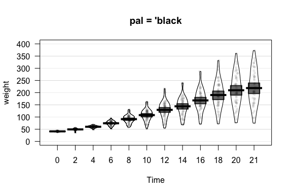

```r
pirateplot(formula = weight ~ Time,
           data = ChickWeight,
           theme = 2,
           pal = "black",
           main = "pal = 'black")
```

# Customising elements

Regardless of the theme you use, you can always customize the color and opacity of graphical elements. To do this, specify one of the following arguments. Note: Arguments with `.f.` correspond to the *filling* of an element, while `.b.` correspond to the *border* of an element:

Customising plotting elements

| element | color | opacity |
| --- | --- | --- |
| points | point.col, point.bg | point.o |
| beans | bean.f.col, bean.b.col | bean.f.o, bean.b.o |
| bar | bar.f.col, bar.b.col | bar.f.o, bar.b.o |
| inf | inf.f.col, inf.b.col | inf.f.o, inf.b.o |
| avg.line | avg.line.col | avg.line.o |

For example, I could create the following pirateplots using `theme = 0` and specifying elements explicitly:

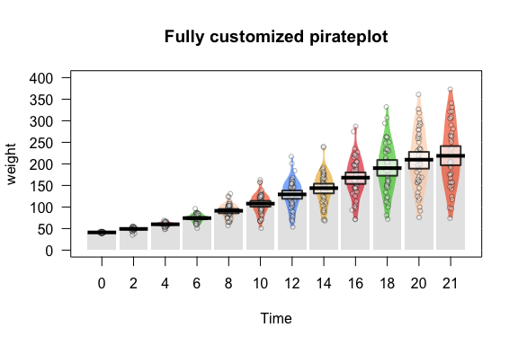

```r
pirateplot(formula = weight ~ Time,
           data = ChickWeight,
           theme = 0,
           main = "Fully customized pirateplot",
           pal = "southpark", # southpark color palette
           bean.f.o = .6, # Bean fill
           point.o = .3, # Points
           inf.f.o = .7, # Inference fill
           inf.b.o = .8, # Inference border
           avg.line.o = 1, # Average line
           bar.f.o = .5, # Bar
           inf.f.col = "white", # Inf fill col
           inf.b.col = "black", # Inf border col
           avg.line.col = "black", # avg line col
           bar.f.col = gray(.8), # bar filling color
           point.pch = 21,
           point.bg = "white",
           point.col = "black",
           point.cex = .7)
```

If you don’t want to start from scratch, you can also start with a theme, and then make selective adjustments:

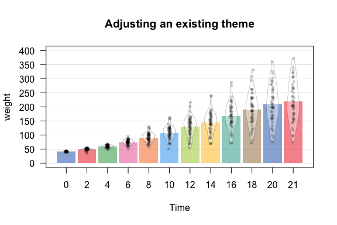

```r
pirateplot(formula = weight ~ Time,
           data = ChickWeight,
           main = "Adjusting an existing theme",
           theme = 2,  # Start with theme 2
           inf.f.o = 0, # Turn off inf fill
           inf.b.o = 0, # Turn off inf border
           point.o = .2,   # Turn up points
           bar.f.o = .5, # Turn up bars
           bean.f.o = .4, # Light bean filling
           bean.b.o = .2, # Light bean border
           avg.line.o = 0, # Turn off average line
           point.col = "black" # Black points
           )
```

Just to drive the point home, as a barplot is a special case of a pirateplot, you can even reduce a pirateplot into a horrible barplot:

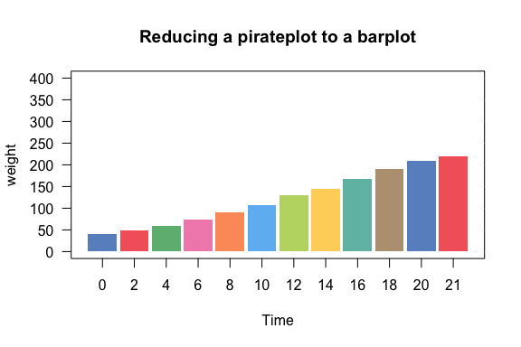

```r
pirateplot(formula = weight ~ Time,
           data = ChickWeight,
           main = "Reducing a pirateplot to a barplot",
           theme = 0, # Start from scratch
           bar.f.o = .7) # Just turn on the bars
```

# Additional arguments

There are several more arguments that you can use to customize your plot:

Additonal pirateplot elements

| element | arguments | examples |
| --- | --- | --- |
| Background color | back.col | back.col = ‘gray(.9, .9)’ |
| Gridlines | gl.col, gl.lwd, gl.lty | gl.col = ‘gray’, gl.lwd = c(.75, 0), gl.lty = 1 |
| Quantiles | quant, quant.lwd, quant.col | quant = c(.1, .9), quant.lwd = 1, quant.col = ‘black’ |
| Average line | avg.line.fun | avg.line.fun = median |
| Inference Calculation | inf.method | inf.method = ‘hdi’, inf.method = ‘ci’ |
| Inference Display | inf.disp | inf.disp = ‘line’, inf.disp = ‘bean’, inf.disp = ‘rect’ |

Here’s an example using a background color, and quantile lines.

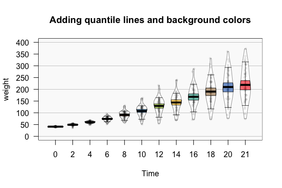

```r
pirateplot(formula = weight ~ Time,
           data = ChickWeight,
           main = "Adding quantile lines and background colors",
           theme = 2,
           back.col = gray(.98), # Add light gray background
           gl.col = "gray", # Gray gridlines
           gl.lwd = c(.75, 0),
           inf.f.o = .6, # Turn up inf filling
           inf.disp = "bean", # Wrap inference around bean
           bean.b.o = .4, # Turn down bean borders
           quant = c(.1, .9), # 10th and 90th quantiles
           quant.col = "black" # Black quantile lines
           )
```

# Multiple IVs

You can use up to 3 categorical IVs in your plot. Here are some examples:

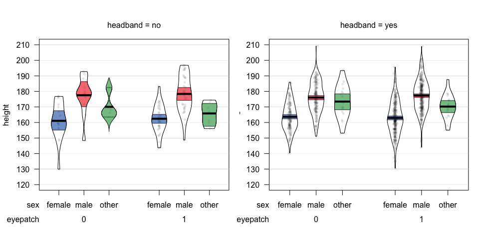

```r
pirateplot(formula = height ~ sex + eyepatch + headband,
           data = pirates,
           theme = 2,
           inf.disp = "bean")
```

Here’s a pirateplot with showing the relationship between movie running times based on movie genre and whether the movie is a sequel or not.

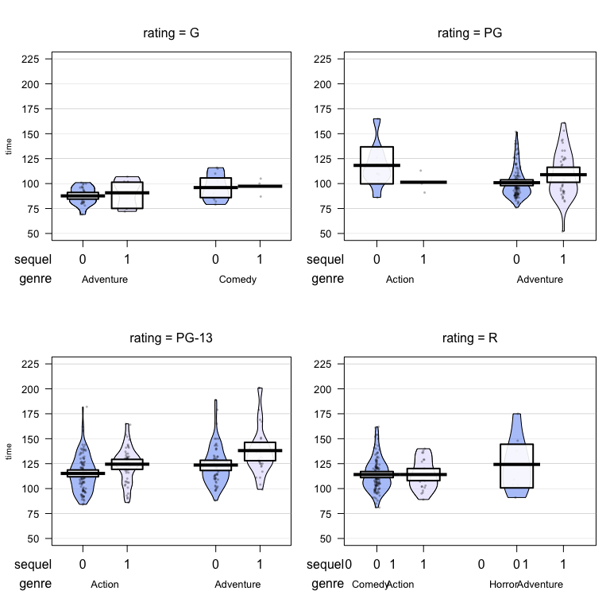

```r
pirateplot(formula = time ~ sequel + genre + rating,
           data = subset(movies,
                         genre %in% c("Action", "Adventure", "Comedy", "Horror") &
                         rating %in% c("G", "PG", "PG-13", "R") &
                         time > 0),
           theme = 3,
           cex.lab = .8,
           inf.disp = "rect",
           pal = "up")
```

# Output

If you include the `plot = FALSE` argument to a pirateplot, the function will return some values associated with the plot.

```r
times.pp <- pirateplot(formula = time ~ sequel + genre,
                       data = subset(movies,
                         genre %in% c("Action", "Adventure", "Comedy", "Horror") &
                         rating %in% c("G", "PG", "PG-13", "R") &
                         time > 0),
                         plot = FALSE)
```

Here’s the result. The most interesting element is `$summary` which shows summary statistics for each bean:

```r
times.pp
```

```
## $summary
##   sequel     genre bean.num   n       avg    inf.lb   inf.ub
## 1      0    Action        1 233 114.73391 112.54208 116.9171
## 2      1    Action        2  80 120.47500 116.47585 124.5282
## 3      0 Adventure        3 206 106.36408 103.33926 109.1894
## 4      1 Adventure        4  78 118.64103 111.37081 124.0271
## 5      0    Comedy        5 400 102.01500 100.92166 103.1729
## 6      1    Comedy        6  51 101.21569  98.31366 103.8705
## 7      0    Horror        7  79 102.13924  98.43406 105.3444
## 8      1    Horror        8  23  97.65217  92.99968 102.9126
##
## $avg.line.fun
## [1] "mean"
##
## $inf.method
## [1] "hdi"
##
## $inf.p
## [1] 0.95
```

# Contribute!

I am very happy to receive new contributions and suggestions to improve the pirateplot. If you come up a new theme (i.e.; customization) that you like, or have a favorite color palette that you’d like to have implemented, please contact me (yarrr.book@gmail.com) or post an issue at www.github.com/ndphillips/yarrr/issues and I might include it in a future update.

# References

The pirateplot is really a knock-off of the great beanplot package and visualization from Kampstra and others (2008).

Kampstra, Peter, and others. 2008. “Beanplot: A Boxplot Alternative for Visual Comparison of Distributions.” *Journal of Statistical Software* 28 (1): 1–9.